# K-Means Assignment

*Setting default values to get a clean output*

```r
knitr::opts_chunk$set(message = FALSE)
knitr::opts_chunk$set(warning = FALSE)
```

*Loading the required packages*

```r
library("tidyverse")
library("factoextra")
library("ggplot2")
library("dplyr")
```

*Loading the data*

```r
pharma.df <- read.csv("Pharmaceuticals.csv")
```

*Looking for na values*

```r
colMeans(is.na(pharma.df))
```

```
               Symbol                  Name
                    0                     0
           Market_Cap                  Beta
                    0                     0
             PE_Ratio                   ROE
                    0                     0
                  ROA        Asset_Turnover
                    0                     0
             Leverage            Rev_Growth
                    0                     0
    Net_Profit_Margin Median_Recommendation
                    0                     0
             Location              Exchange
                    0                     0
```

*Normalization and finding the optimal k*

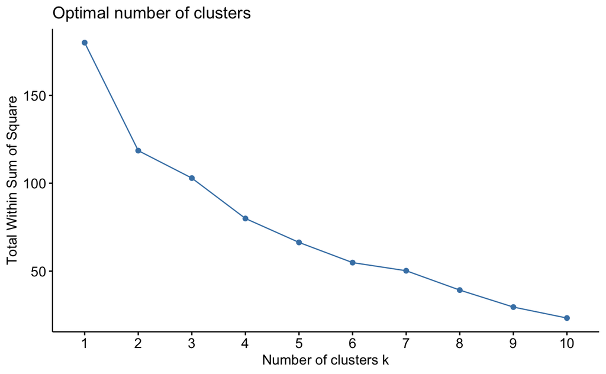

```r
pharma.df.norm <- scale(pharma.df[,-c(1:2,12:14)])

wss <- fviz_nbclust(pharma.df.norm,kmeans,method="wss")
wss
```

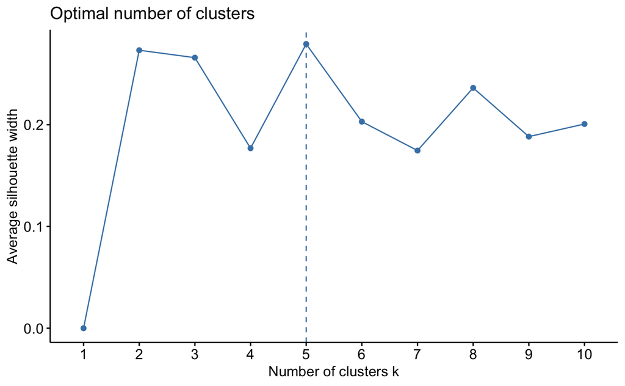

```r
silhouette <- fviz_nbclust(pharma.df.norm,kmeans,method="silhouette")
silhouette
```

*The optimal k thereby received using the wss method is k = 2 whereas by employing the silhouette method the optimal k received was k = 5.*

*Formulation of clusters using K-Means with k = 2 (WSS)*

```r
wss_kmeans <- kmeans(pharma.df.norm,centers = 2,nstart=25)
wss_kmeans
```

```
K-means clustering with 2 clusters of sizes 11, 10

Cluster means:
  Market_Cap       Beta   PE_Ratio        ROE        ROA
1  0.6733825 -0.3586419 -0.2763512  0.6565978  0.8344159
2 -0.7407208  0.3945061  0.3039863 -0.7222576 -0.9178575
  Asset_Turnover   Leverage Rev_Growth Net_Profit_Margin
1      0.4612656 -0.3331068 -0.2902163         0.6823310
2     -0.5073922  0.3664175  0.3192379        -0.7505641

Clustering vector:
 [1] 1 2 2 1 2 2 1 2 2 1 1 2 1 2 1 1 1 2 1 2 1

Within cluster sum of squares by cluster:
[1] 43.30886 75.26049
 (between_SS / total_SS =  34.1 %)

Available components:

[1] "cluster"      "centers"      "totss"
[4] "withinss"     "tot.withinss" "betweenss"
[7] "size"         "iter"         "ifault"
```

*Formulation of clusters using K-Means with k = 5 (Silhouette)*

```r
silhouette_kmeans <- kmeans(pharma.df.norm,centers=5,nstart=25)
silhouette_kmeans
```

```
K-means clustering with 5 clusters of sizes 3, 2, 8, 4, 4

Cluster means:
   Market_Cap       Beta    PE_Ratio        ROE        ROA
1 -0.87051511  1.3409869 -0.05284434 -0.6184015 -1.1928478
2 -0.43925134 -0.4701800  2.70002464 -0.8349525 -0.9234951
3 -0.03142211 -0.4360989 -0.31724852  0.1950459  0.4083915
4  1.69558112 -0.1780563 -0.19845823  1.2349879  1.3503431
5 -0.76022489  0.2796041 -0.47742380 -0.7438022 -0.8107428
  Asset_Turnover    Leverage Rev_Growth Net_Profit_Margin
1     -0.4612656  1.36644699 -0.6912914      -1.320000179
2      0.2306328 -0.14170336 -0.1168459      -1.416514761
3      0.1729746 -0.27449312 -0.7041516       0.556954446
4      1.1531640 -0.46807818  0.4671788       0.591242521
5     -1.2684804  0.06308085  1.5180158      -0.006893899

Clustering vector:
 [1] 3 2 3 3 5 1 3 1 5 3 4 1 4 5 4 3 4 2 3 5 3

Within cluster sum of squares by cluster:
[1] 15.595925  2.803505 21.879320  9.284424 12.791257
 (between_SS / total_SS =  65.4 %)

Available components:

[1] "cluster"      "centers"      "totss"
[4] "withinss"     "tot.withinss" "betweenss"
[7] "size"         "iter"         "ifault"
```

*Cluster Plot (WSS)*

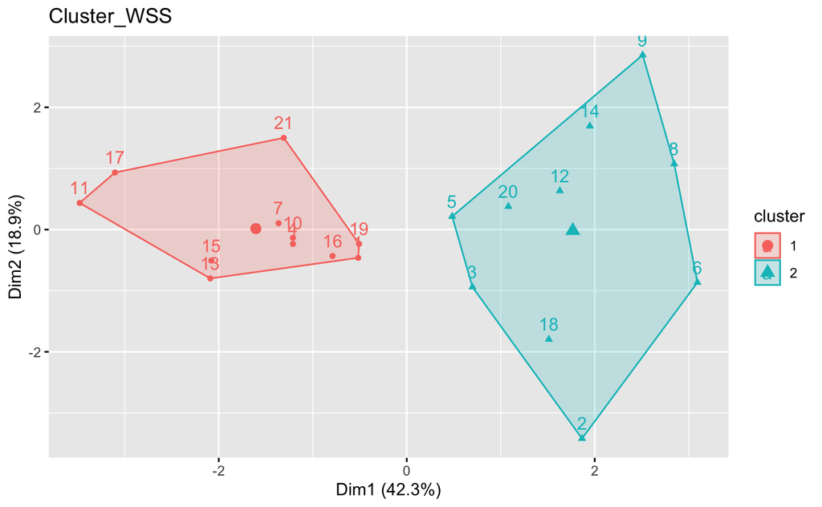

```r
fviz_cluster(wss_kmeans,pharma.df[,-c(1:2,12:15)],main="Cluster_WSS")
```

*By employing the WSS Method we get 2 clusters of size 11 and 10.*

*Cluster Plot (Silhouette)*

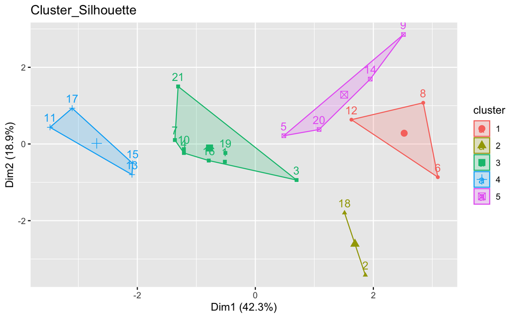

```r
fviz_cluster(silhouette_kmeans,pharma.df[,-c(1:2,12:15)],main="Cluster_Silhouette")
```

*By employing the Silhouette Method we get 5 clusters of size 3, 2, 8, 4 and 4.*

*Binding the cluster assignment to the original data frame for analysis*

```r
clusters_wss <- wss_kmeans$cluster
clusters_silhouette <- silhouette_kmeans$cluster

pharma.df.1 <- cbind(pharma.df,clusters_wss)
pharma.df.2 <- cbind(pharma.df,clusters_silhouette)
```

*Aggregating the clusters to interpret the attributes - WSS*

```r
int_wss <- aggregate(pharma.df.1[,-c(1:2,12:14)],by=list(pharma.df.1$clusters_wss),FUN="median")
print(int_wss[,-1])
```

| Market_Cap | Beta | PE_Ratio | ROE | ROA | Asset_Turnover | Leverage | Rev_Growth | Net_Profit_Margin | clusters_wss |
| --- | --- | --- | --- | --- | --- | --- | --- | --- | --- |
| 73.84 | 0.460 | 21.50 | 31.0 | 15.0 | 0.8 | 0.280 | 8.560 | 20.6 | 1 |
| 4.78 | 0.555 | 23.35 | 14.2 | 5.6 | 0.6 | 0.475 | 14.495 | 11.1 | 2 |

*Interpretation:* *Note: The interpretation is solely based on the financial attributes of the given firms in each of the clusters, the interpretation obtained would be thereby helping an individual to take a decision regarding choosing an cluster among the two to invest in order to gain profits.* *Acceptable Profitability with Moderate Risk* *The First cluster here obtained is a good investment because of the high probability of success. The success is defined here with the help of the attributes “Market Capital”, ROE - Return on Expenditure, ROA - Return on Assets, Asset Turnover and Net Profit Margin. The capital value in this cluster is 73.84, ROE which basically helps us know the returns on the money we put in as investment is high i.e. 31 and that of ROA which is the returns a firm expects to receive on the money they invest on the assets is also high i.e. 15. Similarly the turnover on the assets and net profit is high as well.The PE Ratio is less with that of the second cluster indicating that the company is properly valued without any disparity in it’s share prices.* *The level of risk in this investment is low which is called out by the “Beta” value, generally beta value should be lower than 1 in this case it is 0.46 which refers that the variability in these firms would be moderate not having enough of fluctuations.Also the “Leverage” value, which refers to a firm having borrowed capital for an investment should be as less as possible because market is always unpredictable and there would be possibilities of a firm loosing the money which they have borrowed for an investment expecting profits in return. Here the leverage value is 0.28 which is comparatively less to the second cluster. “With a good investment there should be very little chance of losing the total amount invested” and the group of firms in this cluster are expressing higher success rate when compared to that with the second cluster.* *Low Profitability with High Risk* *Here, the second cluster is having poor performance metrics when compared with that with the first cluster, the market capital is very less i.e. 4.78 with that of 73.84 in first cluster, this shows the firms listed in this cluster are having less market share when compared to that with the first cluster. Return on Expenditure (ROE), Return on Assets (ROA), Asset Turnover, Net Profit Margin is less as well. The level of risk which is called out by the Beta and Leverage value is high in these firms which means that there is high variability and high borrowings in these firms with contrast to that with the first cluster. Comparatively the PE Ratio is high as well stating that the company’s share value is overvalued, making it as a negative mark to these companies.*

*Pattern in the categorical variables*

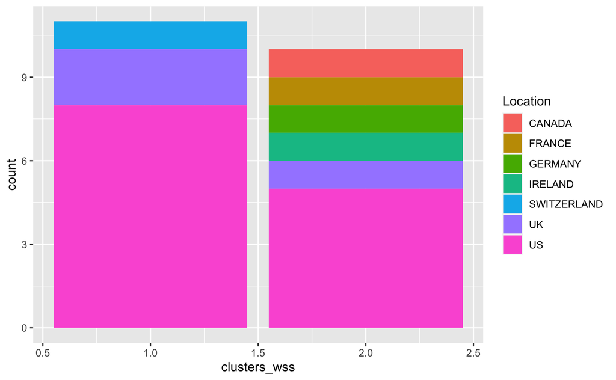

```r
ggplot(pharma.df.1,aes(x=clusters_wss,fill=Location)) + geom_bar()
```